# Homework 01

## Question 1 (Least squares and matrix calculations)

Set the random seed to 43201. Generate $n=100$ observations with $p=5$ predictors according to

$$x_{ij}\overset{\mathrm{iid}}{\sim}N(0,1),
\qquad
\varepsilon_i\overset{\mathrm{iid}}{\sim}N(0,0.7^2),$$

with all predictors and errors generated independently. Let

$$\mathbf X
=
\begin{bmatrix}
\mathbf 1 & \mathbf x_1 & \cdots & \mathbf x_5
\end{bmatrix},
\qquad
\boldsymbol\beta
=
(3,1.4,-0.9,0.7,0,1.1)^{\mathsf T},$$

and generate

$$\mathbf y=\mathbf X\boldsymbol\beta+\boldsymbol\varepsilon.$$

1. Generate the data and report the dimensions and rank of $\mathbf X$. Calculate the least-squares estimate $\widehat{\boldsymbol\beta}$ using a numerically stable least-squares routine, without explicitly calculating $(\mathbf X^{\mathsf T}\mathbf X)^{-1}$. Compare the estimates with the coefficients used to generate the data.

### Answer to 1(a)

```python
import numpy as np
import pandas as pd
import matplotlib.pyplot as plt
from scipy import optimize

rng = np.random.default_rng(43201)
n = 100
p = 5
predictors = rng.normal(size=(n, p))
X = np.column_stack((np.ones(n), predictors))
beta = np.array([3, 1.4, -0.9, 0.7, 0, 1.1])
epsilon = rng.normal(loc=0, scale=0.7, size=n)
y = X @ beta + epsilon

beta_hat, _, rank, _ = np.linalg.lstsq(X, y, rcond=None)
coefficient_names = ["Intercept", "x1", "x2", "x3", "x4", "x5"]
coefficient_comparison = pd.DataFrame({
    "coefficient": coefficient_names,
    "true": beta,
    "estimated": beta_hat,
})

print(f"Dimensions of X: {X.shape}")
print(f"Rank of X: {rank}")
coefficient_comparison.round(4)
```

```
Dimensions of X: (100, 6)
Rank of X: 6
```

|  | coefficient | true | estimated |
| --- | --- | --- | --- |
| 0 | Intercept | 3.0 | 2.9731 |
| 1 | x1 | 1.4 | 1.3240 |
| 2 | x2 | -0.9 | -0.8415 |
| 3 | x3 | 0.7 | 0.7204 |
| 4 | x4 | 0.0 | -0.0831 |
| 5 | x5 | 1.1 | 1.1651 |

$\mathbf X$ has 100 rows and 6 columns because it contains five predictors and one intercept column. Its rank is 6, so it has full column rank and the least-squares solution is unique. The estimates are reasonably close to the generating coefficients but are not identical because $\mathbf y$ contains random Gaussian noise. In particular, the estimate for $x_4$ is near its true coefficient of zero.

2. Calculate the fitted values, the residual vector $\mathbf r=\mathbf y-\mathbf X\widehat{\boldsymbol\beta}$, and the training root mean squared error

$$\operatorname{RMSE}
=
\left(
\frac{1}{n}\sum_{i=1}^{n}r_i^2
\right)^{1/2}.$$

### Answer to 1(b)

```python
fitted = X @ beta_hat
residuals = y - fitted
rmse = np.sqrt(np.mean(residuals**2))
print(f"Training RMSE: {rmse:.6f}")
```

```
Training RMSE: 0.646340
```

The training RMSE is approximately $0.646340$.

3. Report $\lVert\mathbf X^{\mathsf T}\mathbf r\rVert_\infty$. Explain why this value should be close to zero and what it tells us about the residual vector.

### Answer to 1(c)

```python
normal_equation_norm = np.linalg.norm(X.T @ residuals, ord=np.inf)
print(f"Infinity norm: {normal_equation_norm:.6e}")
print(f"Sum of residuals: {residuals.sum():.6e}")
```

```
Infinity norm: 1.457584e-12
Sum of residuals: 1.234568e-13
```

The value is approximately $1.46\times 10^{-12}$. Least squares satisfies the normal equations

$$\mathbf X^{\mathsf T}(\mathbf y-\mathbf X\widehat{\boldsymbol\beta})
=\mathbf X^{\mathsf T}\mathbf r=\mathbf 0.$$

Thus the residual vector is approximately orthogonal to every column of $\mathbf X$. Because one column is the intercept, the residuals also sum to approximately zero. The tiny nonzero values arise from floating-point arithmetic.

## Question 2 (Gaussian likelihood for linear regression)

Continue with the data from Question 1. Suppose

$$\mathbf Y\mid\mathbf X
\sim
N_n\left(\mathbf X\boldsymbol\beta,\sigma^2\mathbf I_n\right).$$

The log-likelihood, including the constant term, is

$$\ell(\boldsymbol\beta,\sigma^2)
=
-\frac{n}{2}\log(2\pi\sigma^2)
-\frac{1}{2\sigma^2}
(\mathbf y-\mathbf X\boldsymbol\beta)^{\mathsf T}
(\mathbf y-\mathbf X\boldsymbol\beta).$$

1. For fixed $\sigma^2$, explain why maximizing $\ell(\boldsymbol\beta,\sigma^2)$ over $\boldsymbol\beta$ is equivalent to minimizing the residual sum of squares. What does this imply about the maximum-likelihood estimate of $\boldsymbol\beta$?

### Answer to 2(a)

Define

$$\operatorname{RSS}(\boldsymbol\beta)
=(\mathbf y-\mathbf X\boldsymbol\beta)^{\mathsf T}
(\mathbf y-\mathbf X\boldsymbol\beta).$$

For fixed $\sigma^2$, the first term of the log-likelihood is constant in $\boldsymbol\beta$, and

$$\ell(\boldsymbol\beta,\sigma^2)
=C-\frac{1}{2\sigma^2}\operatorname{RSS}(\boldsymbol\beta).$$

Since $1/(2\sigma^2)>0$, maximizing the log-likelihood is equivalent to minimizing RSS. Therefore, $\widehat{\boldsymbol\beta}_{\mathrm{MLE}}$ is the least-squares estimate $\widehat{\boldsymbol\beta}$ calculated in Question 1.

2. For fixed $\boldsymbol\beta$, differentiate the log-likelihood with respect to $\sigma^2$ and derive its maximum-likelihood estimate. Calculate this estimate at $\widehat{\boldsymbol\beta}$ and compare it with the unbiased estimate of $\sigma^2$. Explain why the two denominators differ.

### Answer to 2(b)

Holding $\boldsymbol\beta$ fixed and writing $\operatorname{RSS}=\operatorname{RSS}(\boldsymbol\beta)$,

$$\frac{\partial\ell}{\partial\sigma^2}
=-\frac{n}{2\sigma^2}+\frac{\operatorname{RSS}}{2(\sigma^2)^2}.$$

Setting this derivative to zero and multiplying by $2(\sigma^2)^2$ gives

$$-n\sigma^2+\operatorname{RSS}=0,
\qquad
\widehat\sigma^2_{\mathrm{MLE}}=\frac{\operatorname{RSS}}{n}.$$

To confirm that this stationary point is a maximum, let $v=\sigma^2$. Then

$$\frac{d^2\ell}{dv^2}
=\frac{n}{2v^2}-\frac{\operatorname{RSS}}{v^3}.$$

At $\widehat v=\operatorname{RSS}/n$, we have $\operatorname{RSS}=n\widehat v$. Therefore,

$$\left.\frac{d^2\ell}{dv^2}\right|_{v=\widehat v}
=\frac{n}{2\widehat v^2}-\frac{n}{\widehat v^2}
=-\frac{n}{2\widehat v^2}<0.$$

Thus the stationary point is a maximum, confirming that $\widehat{\sigma}^2_{\mathrm{MLE}}=\operatorname{RSS}/n$.

```python
rss = residuals @ residuals
sigma2_mle = rss / n
sigma2_unbiased = rss / (n - X.shape[1])
pd.DataFrame({
    "estimator": ["MLE", "Unbiased"],
    "denominator": [n, n - X.shape[1]],
    "estimate": [sigma2_mle, sigma2_unbiased],
}).round(6)
```

|  | estimator | denominator | estimate |
| --- | --- | --- | --- |
| 0 | MLE | 100 | 0.417755 |
| 1 | Unbiased | 94 | 0.444420 |

The MLE is $0.417755$, while the unbiased estimate is $0.444420$. Maximum likelihood divides by $n$. The unbiased estimator divides by $n-6=94$ because estimating six regression coefficients uses six degrees of freedom; this adjustment corrects the downward bias in RSS divided by $n$.

3. Let

$$\mathbf e_{x_2}=(0,0,1,0,0,0)^{\mathsf T}.$$

Using the variance estimate from part b, plot

$$\ell\left(
\widehat{\boldsymbol\beta}+t\mathbf e_{x_2},
\widehat{\sigma}_{\mathrm{MLE}}^2
\right)$$

over a grid of $t$ values from $-1.25$ to $1.25$. State where the maximum occurs and explain why this agrees with the least-squares result.

### Answer to 2(c)

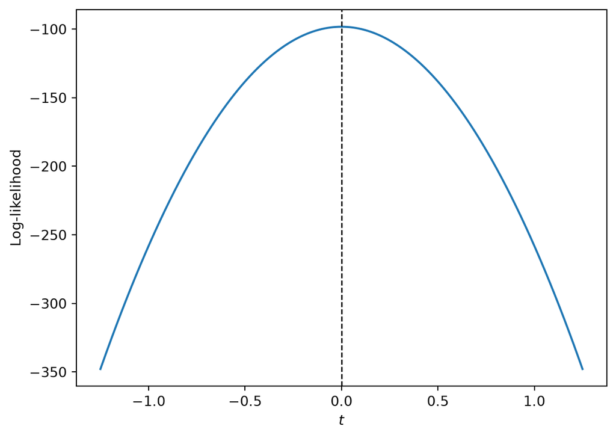

Gaussian log-likelihood along the x2 coefficient direction.

```
Grid maximum occurs at t = 0.000
```

```python
e_x2 = np.array([0, 0, 1, 0, 0, 0])
t_grid = np.linspace(-1.25, 1.25, 501)

def log_likelihood(beta_value, sigma2):
    current_residuals = y - X @ beta_value
    return (
        -n / 2 * np.log(2 * np.pi * sigma2)
        - (current_residuals @ current_residuals) / (2 * sigma2)
    )

log_likelihood_values = np.array([
    log_likelihood(beta_hat + t * e_x2, sigma2_mle)
    for t in t_grid
])
maximizing_t = t_grid[np.argmax(log_likelihood_values)]

fig, ax = plt.subplots()
ax.plot(t_grid, log_likelihood_values)
ax.axvline(0, color="black", linestyle="--", linewidth=1)
ax.set(xlabel="$t$", ylabel="Log-likelihood")
plt.show()
print(f"Grid maximum occurs at t = {maximizing_t:.3f}")
```

The grid maximum occurs at $t=0$, so moving the $x_2$ coefficient in either direction from its least-squares estimate lowers the log-likelihood. This agrees with part (a), where maximizing the Gaussian likelihood in $\boldsymbol\beta$ was shown to be equivalent to minimizing RSS.

## Question 3 (Starting values in nonconvex optimization)

Consider the function

$$f(x)=\exp(1.5x)-3(x+6)^2-0.05x^3,$$

with derivative

$$f'(x)=1.5\exp(1.5x)-6(x+6)-0.15x^2.$$

1. Plot $f(x)$ over the interval $[-40,7]$. Based on the plot, describe the important features of the objective function that may affect numerical optimization.

### Answer to 3(a)

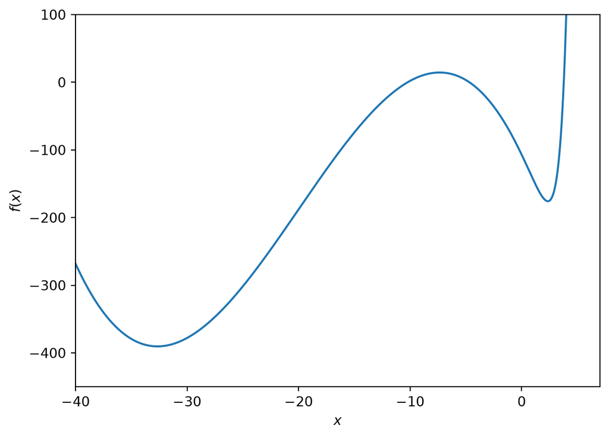

The nonconvex objective over the requested interval.

```python
def objective_scalar(x):
    return np.exp(1.5 * x) - 3 * (x + 6) ** 2 - 0.05 * x**3

plot_x = np.linspace(-40, 7, 1000)
fig, ax = plt.subplots()
ax.plot(plot_x, objective_scalar(plot_x))
ax.set(xlabel="$x$", ylabel="$f(x)$")
ax.set_xlim(-40, 7)
ax.set_ylim(-450, 100)
plt.show()
```

The displayed vertical range is restricted to make both low regions visible; this does not change the objective. The plot is nonconvex and shows multiple basins with distinct local minima separated by a local maximum. The exponential term also makes the objective rise very rapidly at the right side of the interval. Consequently, a local optimizer can converge to different stationary points depending on its starting value.

2. Use BFGS to minimize $f(x)$ twice, starting at $x^{(0)}=-15$ and $x^{(0)}=0$. Supply $f'(x)$ to the optimizer. For each run, report the final value of $x$, the final objective value, $|f'(x)|$, and whether the optimizer reported convergence.

### Answer to 3(b)

```python
def objective(x):
    value = float(np.asarray(x)[0])
    return objective_scalar(value)

def gradient(x):
    value = float(np.asarray(x)[0])
    return np.array([
        1.5 * np.exp(1.5 * value) - 6 * (value + 6) - 0.15 * value**2
    ])

optimization_rows = []
for start in (-15.0, 0.0):
    result = optimize.minimize(
        objective,
        x0=np.array([start]),
        jac=gradient,
        method="BFGS",
    )
    optimization_rows.append({
        "start": start,
        "solution": result.x[0],
        "objective": result.fun,
        "absolute_gradient": abs(gradient(result.x)[0]),
        "converged": result.success,
    })

pd.DataFrame(optimization_rows).round(8)
```

|  | start | solution | objective | absolute_gradient | converged |
| --- | --- | --- | --- | --- | --- |
| 0 | -15.0 | -32.649111 | -390.38577 | 0.000000 | True |
| 1 | 0.0 | 2.349967 | -175.86262 | 0.000008 | True |

Both runs report convergence. Starting from $-15$ gives $x\approx-32.649111$, $f(x)\approx-390.385770$, and $|f'(x)|\approx2.84\times10^{-14}$. Starting from $0$ gives $x\approx2.349967$, $f(x)\approx-175.862620$, and $|f'(x)|\approx8.13\times10^{-6}$.

3. Explain why the two runs can converge to different answers. Which run gives the lower objective value? What additional evidence would be needed before claiming that this point is the global minimum?

### Answer to 3(c)

BFGS is a local optimization method, so on a nonconvex function its result can depend on the starting value. Starting from (-15) and (0) leads the optimizer to different local minima. Among the two runs, the one starting at (-15) gives the lower objective value. However, these two runs alone are not enough to prove that this point is the global minimum. We would need to check whether other stationary points or lower regions of the function exist.

## Question 4 (Nearly collinear predictors)

Continue with $\mathbf X$ and $\mathbf y$ from Question 1. Set the random seed to 43202 and generate

$$u_i\overset{\mathrm{iid}}{\sim}N(0,1),
\qquad i=1,\ldots,n.$$

Define

$$\mathbf x_6=\mathbf x_1+10^{-4}\mathbf u,
\qquad
\mathbf X_+
=
\begin{bmatrix}
\mathbf X & \mathbf x_6
\end{bmatrix},$$

and let

$$\mathbf y^\star=\mathbf y+10^{-3}\mathbf u.$$

Use a numerically stable least-squares routine throughout.

1. Fit $\mathbf y$ using $\mathbf X$ and $\mathbf X_+$. For each design matrix, report the condition number and training RMSE. For the augmented fit, also report the coefficients of $\mathbf x_1$ and $\mathbf x_6$.

### Answer to 4(a)

```python
rng4 = np.random.default_rng(43202)
u = rng4.normal(size=n)
x6 = predictors[:, 0] + 1e-4 * u
X_plus = np.column_stack((X, x6))
y_star = y + 1e-3 * u

beta_X, _, _, _ = np.linalg.lstsq(X, y, rcond=None)
beta_plus, _, _, _ = np.linalg.lstsq(X_plus, y, rcond=None)
fitted_X = X @ beta_X
fitted_plus = X_plus @ beta_plus

pd.DataFrame({
    "design": ["X", "X_plus"],
    "condition_number": [np.linalg.cond(X), np.linalg.cond(X_plus)],
    "training_RMSE": [
        np.sqrt(np.mean((y - fitted_X) ** 2)),
        np.sqrt(np.mean((y - fitted_plus) ** 2)),
    ],
}).round(6)
```

|  | design | condition_number | training_RMSE |
| --- | --- | --- | --- |
| 0 | X | 1.452504 | 0.646340 |
| 1 | X_plus | 20339.835807 | 0.633956 |

For $\mathbf X$, the condition number is $1.452504$ and the training RMSE is $0.646340$. For $\mathbf X_+$, they are $20339.835807$ and $0.633956$, respectively. In the augmented fit, the $x_1$ and $x_6$ coefficients are approximately $-1329.743016$ and $1331.060139$.

2. Fit $\mathbf y^\star$ using $\mathbf X_+$. Report the changes in the coefficients of $\mathbf x_1$ and $\mathbf x_6$. Compare the two fitted-value vectors using their root mean squared difference and maximum absolute difference.

### Answer to 4(b)

```python
beta_star, _, _, _ = np.linalg.lstsq(X_plus, y_star, rcond=None)
fitted_star = X_plus @ beta_star
fitted_difference = fitted_star - fitted_plus

coefficient_changes = pd.DataFrame({
    "coefficient": ["x1", "x6"],
    "fit_y": [beta_plus[1], beta_plus[6]],
    "fit_y_star": [beta_star[1], beta_star[6]],
    "change": [
        beta_star[1] - beta_plus[1],
        beta_star[6] - beta_plus[6],
    ],
})
coefficient_changes.round(6)
```

|  | coefficient | fit_y | fit_y_star | change |
| --- | --- | --- | --- | --- |
| 0 | x1 | -1329.743016 | -1339.743016 | -10.0 |
| 1 | x6 | 1331.060139 | 1341.060139 | 10.0 |

```python
print(
    "Root mean squared fitted-value difference: "
    f"{np.sqrt(np.mean(fitted_difference**2)):.9f}"
)
print(
    "Maximum absolute fitted-value difference: "
    f"{np.max(np.abs(fitted_difference)):.9f}"
)
```

```
Root mean squared fitted-value difference: 0.000974980
Maximum absolute fitted-value difference: 0.002351165
```

The $x_1$ coefficient changes by $-10$ and the $x_6$ coefficient changes by $10$. Nevertheless, the root mean squared fitted-value difference is only $0.000974980$, and the maximum absolute difference is $0.002351165$.

3. Use the identity

$$\mathbf y^\star-\mathbf y
=
10(\mathbf x_6-\mathbf x_1)$$

to explain why the fitted values change very little while the two coefficients change substantially. What does this example suggest about interpreting separate effects for nearly collinear predictors?

### Answer to 4(c)

Increasing the $x_6$ coefficient by 10 and decreasing the $x_1$ coefficient by 10 changes the fitted vector by

$$10\mathbf x_6-10\mathbf x_1
=10(\mathbf x_6-\mathbf x_1)
=10^{-3}\mathbf u
=\mathbf y^\star-\mathbf y.$$

Thus a large, offsetting coefficient change corresponds exactly to the small response perturbation. Nearly collinear columns make individual coefficient estimates highly unstable even when fitted values remain stable. The separate $x_1$ and $x_6$ coefficients therefore should not be interpreted as reliable independent effects.

## Question 5 (Data preparation and summary statistics)

The file `data/data-manipulation.csv` is a small constructed data table containing an observation identifier, a group label, two numeric predictors, and a response. Some response values are missing. For analyses involving the response, use only observations with a recorded response. Do not replace a missing response with zero or a group mean.

1. Read the data and report its dimensions, column types, number of duplicated identifiers, and number of missing values in each column. Create an analysis table containing only observations with a recorded response, and define

$$\texttt{feature\_sum}=\texttt{x1}+\texttt{x2}.$$

### Answer to 5(a)

```python
data = pd.read_csv("data/data-manipulation.csv")
print(f"Dimensions: {data.shape}")
print("\nColumn types:")
print(data.dtypes)
print(f"\nDuplicated identifiers: {data['observation_id'].duplicated().sum()}")
print("\nMissing values by column:")
print(data.isna().sum())

analysis = data.dropna(subset=["response"]).copy()
analysis["feature_sum"] = analysis["x1"] + analysis["x2"]
```

```
Dimensions: (24, 5)

Column types:
observation_id        str
group                 str
x1                float64
x2                float64
response          float64
dtype: object

Duplicated identifiers: 0

Missing values by column:
observation_id    0
group             0
x1                0
x2                0
response          3
dtype: int64
```

The original table has 24 rows and 5 columns. The identifier and group columns are strings, while `x1`, `x2`, and `response` are floating-point numeric columns. There are no duplicated identifiers. Only `response` has missing values, with three missing entries; every other column has zero missing values. After removing the three observations with missing responses, the analysis table contains 21 observations.

2. For each group, report the number of observations, the mean response, and the mean of `feature_sum`. State clearly which observations these summaries describe.

### Answer to 5(b)

```python
group_summary = analysis.groupby("group", as_index=False).agg(
    observations=("response", "size"),
    mean_response=("response", "mean"),
    mean_feature_sum=("feature_sum", "mean"),
)
group_summary.round(6)
```

|  | group | observations | mean_response | mean_feature_sum |
| --- | --- | --- | --- | --- |
| 0 | A | 7 | 5.600000 | 3.600000 |
| 1 | B | 7 | 7.602857 | 4.928571 |
| 2 | C | 7 | 7.997143 | 6.585714 |

These summaries describe only observations with nonmissing recorded responses. Each group retains 7 observations. The mean responses for A, B, and C are $5.600000$, $7.602857$, and $7.997143$, and their mean `feature_sum` values are $3.600000$, $4.928571$, and $6.585714$, respectively.

3. Sort the analysis table by response from largest to smallest and report the first three rows, including `observation_id`, `group`, `response`, and `feature_sum`. Add code checks verifying that the number of retained rows equals the number of nonmissing responses in the original data, that the analysis table has no missing response values, and that its identifiers are unique.

### Answer to 5(c)

```python
top_three = analysis.sort_values("response", ascending=False).head(3)[
    ["observation_id", "group", "response", "feature_sum"]
]

assert len(analysis) == data["response"].notna().sum()
assert analysis["response"].notna().all()
assert analysis["observation_id"].is_unique

top_three
```

|  | observation_id | group | response | feature_sum |
| --- | --- | --- | --- | --- |
| 21 | obs-22 | C | 9.24 | 6.6 |
| 15 | obs-16 | B | 9.00 | 5.2 |
| 13 | obs-14 | B | 8.66 | 5.0 |

All three validation checks pass. The highest-response rows are `obs-22` (C, $9.24$, $6.6$), `obs-16` (B, $9.00$, $5.2$), and `obs-14` (B, $8.66$, $5.0$), where the final value in each tuple is `feature_sum`.

## Question 6 (Can 39 million Fitbit records represent US adults?)

[Patten et al. (2026)](https://doi.org/10.1038/s41591-026-04352-3) describe Fitbit data from 59,018 participants in the All of Us Research Program. The dataset spans 14 years and contains more than 39 million daily step records. Participants contributed data through one of two routes:

- Bring Your Own Device (BYOD): participants shared data from a Fitbit they already owned.
- Wearables Enhancing All of Us Research (WEAR): invited participants received a Fitbit at no cost.

In the general activity cohort, the BYOD and WEAR groups contained 32,035 and 22,474 participants, respectively. The BYOD value is listed first in each comparison below:

- 77.3% versus 55.1% reported being White;
- 6.1% versus 15.2% reported annual household income between $\$10{,}000$ and $\$25{,}000$; and
- median daily steps were 6,867 versus 5,797.

Suppose the target is the mean of the participant-specific average daily step counts among US adults during the study period, with each adult given equal weight. A researcher writes:

> “This dataset contains more than 39 million daily Fitbit records. Therefore, the average of all recorded step counts should provide an accurate estimate of mean daily activity among US adults.”
1. Are the 39 million daily records independent observations? What characteristics or behaviors could cause some participants to contribute more recorded days than others? Explain how averaging all recorded days would then weight participants unequally.

### Answer to 6(a)

The daily records are not independent because repeated measurements from the same participant share that person’s characteristics and behavior and can be correlated over time. Participants can contribute different numbers of days because of enrollment time, Fitbit ownership duration, device wear and charging habits, adherence, device connection, willingness to share, and whether a day yields a valid record. Averaging all daily records gives a participant weight proportional to the number of recorded days, rather than giving each participant equal weight as required by the target quantity. Thus 39 million records do not represent 39 million independent people.

2. BYOD participants reported a median of 6,867 daily steps, compared with 5,797 among WEAR participants. Does this comparison show that already owning a Fitbit causes people to walk more? Explain your answer and give at least one plausible alternative explanation based on how participants entered the two groups.

### Answer to 6(b)

No. BYOD and WEAR are routes of entry, not automatically randomized treatment groups, so the observed difference does not identify a causal effect of Fitbit ownership. People who already owned a Fitbit may differ in activity, health interest, income, access to technology, or willingness to share wearable data. The reported demographic differences between the groups also show that their compositions differ. Any of these preexisting differences could help explain the step-count comparison.

3. A very large dataset can still produce a biased estimate of a population quantity when the people and observations entering the dataset are selected. Using this study, explain how selection of both participants and recorded days could make the observed data differ from the US adult population. Why might the naive average of all recorded daily step counts fail to estimate the stated target? You do not need to determine the direction of the bias.

### Answer to 6(c)

Participants first must enter the All of Us program and then enter the Fitbit dataset through ownership and sharing or through invitation and acceptance of a supplied device. Wearable access, willingness to participate and share, device connection, and adherence can therefore select participants who differ from US adults generally. The BYOD and WEAR demographic differences illustrate that these mechanisms can change the composition of the observed sample.

Selection also occurs at the day level: wearing, syncing, and producing a valid record can depend on the participant and possibly on daily behavior. A naive daily-record average both excludes unobserved adults and days and gives more weight to participants with more recorded days. Its large volume reduces random variability around the quantity represented by those records, but it does not remove systematic selection or align the weighting with the target mean of participant-specific averages among US adults.

### Source

Patten, T., Preble, E. A., Master, H., et al. (2026). [The All of Us Research Program’s wearables dataset](https://doi.org/10.1038/s41591-026-04352-3). *Nature Medicine*, 32, 2302-2310.